# World

2024-08-11

# Data-Sets

We have a World Population data-set consisting records of population from the year 1960 to 2023.

## Total Polulation data-set

| Country.Name | Country.Code | Indicator.Name | Indicator.Code | X1960 | X1961 | X1962 | X1963 | X1964 | X1965 | X1966 | X1967 | X1968 | X1969 | X1970 | X1971 | X1972 | X1973 | X1974 | X1975 | X1976 | X1977 | X1978 | X1979 | X1980 | X1981 | X1982 | X1983 | X1984 | X1985 | … |
| --- | --- | --- | --- | --- | --- | --- | --- | --- | --- | --- | --- | --- | --- | --- | --- | --- | --- | --- | --- | --- | --- | --- | --- | --- | --- | --- | --- | --- | --- | --- |
| Afghanistan | AFG | Population, total | SP.POP.TOTL | 8622466 | 8790140 | 8969047 | 9157465 | 9355514 | 9565147 | 9783147 | 10010030 | 10247780 | 10494489 | 10752971 | 11015857 | 11286753 | 11575305 | 11869879 | 12157386 | 12425267 | 12687301 | 12938862 | 12986369 | 12486631 | 11155195 | 10088289 | 9951449 | 10243686 | 10512221 | … |
| Albania | ALB | Population, total | SP.POP.TOTL | 1608800 | 1659800 | 1711319 | 1762621 | 1814135 | 1864791 | 1914573 | 1965598 | 2022272 | 2081695 | 2135479 | 2187853 | 2243126 | 2296752 | 2350124 | 2404831 | 2458526 | 2513546 | 2566266 | 2617832 | 2671997 | 2726056 | 2784278 | 2843960 | 2904429 | 2964762 | … |
| Algeria | DZA | Population, total | SP.POP.TOTL | 11394307 | 11598608 | 11778260 | 11969451 | 12179099 | 12381256 | 12613389 | 12897115 | 13190975 | 13491016 | 13795915 | 14110271 | 14439748 | 14786469 | 15153602 | 15724692 | 16500516 | 17134192 | 17632645 | 18166981 | 18739378 | 19351357 | 20000096 | 20682111 | 21393530 | 22132905 | … |
| American Samoa | ASM | Population, total | SP.POP.TOTL | 20085 | 20626 | 21272 | 21949 | 22656 | 23391 | 24122 | 24848 | 25608 | 26396 | 27075 | 27593 | 28063 | 28529 | 29012 | 29573 | 30198 | 30816 | 31428 | 32045 | 32886 | 34059 | 35367 | 36735 | 38168 | 39663 | … |
| Andorra | AND | Population, total | SP.POP.TOTL | 9443 | 10216 | 11014 | 11839 | 12690 | 13563 | 14546 | 15745 | 17079 | 18449 | 19860 | 21322 | 22832 | 24393 | 26003 | 27640 | 29294 | 30949 | 32574 | 34142 | 35611 | 36987 | 38598 | 40432 | 42181 | 43809 | … |
| Angola | AGO | Population, total | SP.POP.TOTL | 5357195 | 5441333 | 5521400 | 5599827 | 5673199 | 5736582 | 5787044 | 5827503 | 5868203 | 5928386 | 6029700 | 6177049 | 6364731 | 6578230 | 6802494 | 7032713 | 7266780 | 7511895 | 7771590 | 8043218 | 8330047 | 8631457 | 8947152 | 9276707 | 9617702 | 9970621 | … |
| Antigua and Barbuda | ATG | Population, total | SP.POP.TOTL | 55342 | 56245 | 57008 | 57778 | 58664 | 59644 | 60615 | 61617 | 62658 | 63742 | 64517 | 64769 | 64695 | 64463 | 64218 | 64035 | 63990 | 64117 | 64329 | 64609 | 64889 | 65076 | 65231 | 65408 | 65362 | 65048 | … |
| Argentina | ARG | Population, total | SP.POP.TOTL | 20349744 | 20680653 | 21020359 | 21364017 | 21708487 | 22053661 | 22403116 | 22757014 | 23112971 | 23472028 | 23842803 | 24223379 | 24612794 | 25020588 | 25449754 | 25875558 | 26290257 | 26713780 | 27146121 | 27584134 | 28024803 | 28471285 | 28922762 | 29377137 | 29832197 | 30287112 | … |
| Armenia | ARM | Population, total | SP.POP.TOTL | 1904148 | 1971530 | 2039346 | 2106142 | 2171029 | 2234051 | 2295496 | 2355997 | 2416461 | 2476359 | 2534377 | 2590923 | 2648048 | 2706852 | 2767646 | 2830798 | 2896311 | 2965523 | 3038224 | 3097058 | 3135123 | 3167876 | 3202011 | 3238291 | 3272102 | 3300896 | … |
| Aruba | ABW | Population, total | SP.POP.TOTL | 54608 | 55811 | 56682 | 57475 | 58178 | 58782 | 59291 | 59522 | 59471 | 59330 | 59106 | 58816 | 58855 | 59365 | 60028 | 60715 | 61193 | 61465 | 61738 | 62006 | 62267 | 62614 | 63116 | 63683 | 64174 | 64478 | … |

[output cut: 207 more lines]

# Dimension of the data-set

```
[1] 217  68
```

• SP.POP.TOTL (Population,total)

```
 [1] "Country.Name"   "Country.Code"   "Indicator.Name" "Indicator.Code"
 [5] "X1960"          "X1961"          "X1962"          "X1963"
 [9] "X1964"          "X1965"          "X1966"          "X1967"
[13] "X1968"          "X1969"          "X1970"          "X1971"
[17] "X1972"          "X1973"          "X1974"          "X1975"
[21] "X1976"          "X1977"          "X1978"          "X1979"
[25] "X1980"          "X1981"          "X1982"          "X1983"
[29] "X1984"          "X1985"          "X1986"          "X1987"
[33] "X1988"          "X1989"          "X1990"          "X1991"
[37] "X1992"          "X1993"          "X1994"          "X1995"
[41] "X1996"          "X1997"          "X1998"          "X1999"
[45] "X2000"          "X2001"          "X2002"          "X2003"
[49] "X2004"          "X2005"          "X2006"          "X2007"
[53] "X2008"          "X2009"          "X2010"          "X2011"
[57] "X2012"          "X2013"          "X2014"          "X2015"
[61] "X2016"          "X2017"          "X2018"          "X2019"
[65] "X2020"          "X2021"          "X2022"          "X2023"
```

## Female Population data-set

| Country.Name | Country.Code | Indicator.Name | Indicator.Code | X1960 | X1961 | X1962 | X1963 | X1964 | X1965 | X1966 | X1967 | X1968 | X1969 | X1970 | X1971 | X1972 | X1973 | X1974 | X1975 | X1976 | X1977 | X1978 | X1979 | X1980 | X1981 | X1982 | X1983 | X1984 | X1985 | … |
| --- | --- | --- | --- | --- | --- | --- | --- | --- | --- | --- | --- | --- | --- | --- | --- | --- | --- | --- | --- | --- | --- | --- | --- | --- | --- | --- | --- | --- | --- | --- |
| Afghanistan | AFG | Population, female | SP.POP.TOTL.FE.IN | 4145945 | 4233771 | 4326881 | 4424511 | 4526691 | 4634341 | 4745981 | 4861918 | 4983086 | 5108507 | 5239568 | 5372747 | 5509781 | 5655304 | 5803603 | 5948268 | 6083166 | 6214979 | 6342838 | 6373547 | 6136856 | 5490160 | 4973968 | 4916351 | 5074600 | 5225679 | … |
| Albania | ALB | Population, female | SP.POP.TOTL.FE.IN | 785048 | 809475 | 834000 | 858244 | 882448 | 906153 | 929381 | 953152 | 979606 | 1007337 | 1032302 | 1056583 | 1082296 | 1107246 | 1132155 | 1157882 | 1183327 | 1209570 | 1234924 | 1259974 | 1286555 | 1313483 | 1342885 | 1373470 | 1404928 | 1436842 | … |
| Algeria | DZA | Population, female | SP.POP.TOTL.FE.IN | 5647947 | 5747020 | 5823672 | 5903048 | 5985388 | 6061383 | 6163912 | 6302990 | 6446752 | 6593391 | 6742390 | 6896041 | 7057279 | 7227074 | 7407341 | 7690343 | 8074971 | 8388820 | 8636461 | 8902127 | 9187012 | 9491758 | 9814990 | 10154790 | 10508574 | 10875691 | … |
| American Samoa | ASM | Population, female | SP.POP.TOTL.FE.IN | 9771 | 10039 | 10363 | 10703 | 11059 | 11434 | 11802 | 12161 | 12541 | 12944 | 13284 | 13531 | 13748 | 13964 | 14193 | 14466 | 14774 | 15079 | 15379 | 15682 | 16093 | 16654 | 17275 | 17930 | 18618 | 19339 | … |
| Andorra | AND | Population, female | SP.POP.TOTL.FE.IN | 4670 | 5030 | 5402 | 5783 | 6175 | 6577 | 7026 | 7563 | 8156 | 8767 | 9398 | 10056 | 10735 | 11437 | 12165 | 12908 | 13662 | 14424 | 15173 | 15893 | 16559 | 17183 | 17956 | 18869 | 19744 | 20569 | … |
| Angola | AGO | Population, female | SP.POP.TOTL.FE.IN | 2670229 | 2704394 | 2742689 | 2779473 | 2812590 | 2838939 | 2856740 | 2867926 | 2879001 | 2902120 | 2953347 | 3032948 | 3132441 | 3244749 | 3362438 | 3483416 | 3606782 | 3735823 | 3872130 | 4014347 | 4164145 | 4321167 | 4485276 | 4656894 | 4834820 | 5018620 | … |
| Antigua and Barbuda | ATG | Population, female | SP.POP.TOTL.FE.IN | 28965 | 29413 | 29798 | 30191 | 30666 | 31220 | 31777 | 32353 | 32949 | 33569 | 34003 | 34148 | 34142 | 34061 | 33974 | 33917 | 33923 | 34011 | 34135 | 34294 | 34456 | 34568 | 34664 | 34772 | 34682 | 34380 | … |
| Argentina | ARG | Population, female | SP.POP.TOTL.FE.IN | 10158262 | 10335069 | 10513699 | 10694826 | 10876693 | 11058981 | 11243003 | 11429390 | 11617792 | 11808657 | 12005045 | 12208669 | 12419477 | 12639130 | 12869638 | 13096382 | 13315154 | 13538001 | 13764006 | 13991784 | 14220750 | 14453114 | 14688513 | 14924486 | 15159735 | 15392805 | … |
| Armenia | ARM | Population, female | SP.POP.TOTL.FE.IN | 979519 | 1013306 | 1047383 | 1080947 | 1113577 | 1145390 | 1176470 | 1207119 | 1237892 | 1268487 | 1298093 | 1328287 | 1360258 | 1393239 | 1427332 | 1462688 | 1498440 | 1535546 | 1574738 | 1604622 | 1622851 | 1639588 | 1657028 | 1675528 | 1692940 | 1708118 | … |
| Aruba | ABW | Population, female | SP.POP.TOTL.FE.IN | 27773 | 28380 | 28820 | 29218 | 29570 | 29875 | 30135 | 30253 | 30232 | 30166 | 30063 | 29927 | 29953 | 30229 | 30595 | 30972 | 31245 | 31416 | 31584 | 31749 | 31909 | 32121 | 32389 | 32659 | 32886 | 33008 | … |

[output cut: 207 more lines]

# Dimension of the data-set

```
[1] 217  68
```

• SP.POP.TOTL.FE.IN (Population,female)

```
 [1] "Country.Name"   "Country.Code"   "Indicator.Name" "Indicator.Code"
 [5] "X1960"          "X1961"          "X1962"          "X1963"
 [9] "X1964"          "X1965"          "X1966"          "X1967"
[13] "X1968"          "X1969"          "X1970"          "X1971"
[17] "X1972"          "X1973"          "X1974"          "X1975"
[21] "X1976"          "X1977"          "X1978"          "X1979"
[25] "X1980"          "X1981"          "X1982"          "X1983"
[29] "X1984"          "X1985"          "X1986"          "X1987"
[33] "X1988"          "X1989"          "X1990"          "X1991"
[37] "X1992"          "X1993"          "X1994"          "X1995"
[41] "X1996"          "X1997"          "X1998"          "X1999"
[45] "X2000"          "X2001"          "X2002"          "X2003"
[49] "X2004"          "X2005"          "X2006"          "X2007"
[53] "X2008"          "X2009"          "X2010"          "X2011"
[57] "X2012"          "X2013"          "X2014"          "X2015"
[61] "X2016"          "X2017"          "X2018"          "X2019"
[65] "X2020"          "X2021"          "X2022"          "X2023"
```

## Male Population data-set

| Country.Name | Country.Code | Indicator.Name | Indicator.Code | X1960 | X1961 | X1962 | X1963 | X1964 | X1965 | X1966 | X1967 | X1968 | X1969 | X1970 | X1971 | X1972 | X1973 | X1974 | X1975 | X1976 | X1977 | X1978 | X1979 | X1980 | X1981 | X1982 | X1983 | X1984 | X1985 | … |
| --- | --- | --- | --- | --- | --- | --- | --- | --- | --- | --- | --- | --- | --- | --- | --- | --- | --- | --- | --- | --- | --- | --- | --- | --- | --- | --- | --- | --- | --- | --- |
| Afghanistan | AFG | Population, male | SP.POP.TOTL.MA.IN | 4476521 | 4556369 | 4642166 | 4732954 | 4828823 | 4930806 | 5037166 | 5148111 | 5264694 | 5385983 | 5513404 | 5643110 | 5776971 | 5920001 | 6066275 | 6209118 | 6342102 | 6472323 | 6596024 | 6612822 | 6349775 | 5665035 | 5114320 | 5035098 | 5169086 | 5286542 | … |
| Albania | ALB | Population, male | SP.POP.TOTL.MA.IN | 823752 | 850324 | 877319 | 904376 | 931687 | 958638 | 985191 | 1012445 | 1042667 | 1074358 | 1103177 | 1131270 | 1160831 | 1189506 | 1217969 | 1246949 | 1275199 | 1303976 | 1331341 | 1357858 | 1385442 | 1412573 | 1441394 | 1470490 | 1499501 | 1527920 | … |
| Algeria | DZA | Population, male | SP.POP.TOTL.MA.IN | 5746360 | 5851587 | 5954588 | 6066402 | 6193711 | 6319873 | 6449477 | 6594125 | 6744222 | 6897626 | 7053525 | 7214230 | 7382470 | 7559395 | 7746261 | 8034349 | 8425545 | 8745371 | 8996184 | 9264854 | 9552367 | 9859599 | 10185106 | 10527322 | 10884956 | 11257214 | … |
| American Samoa | ASM | Population, male | SP.POP.TOTL.MA.IN | 10314 | 10587 | 10909 | 11246 | 11597 | 11957 | 12320 | 12688 | 13067 | 13452 | 13790 | 14063 | 14315 | 14565 | 14819 | 15107 | 15424 | 15736 | 16049 | 16363 | 16793 | 17406 | 18091 | 18805 | 19550 | 20325 | … |
| Andorra | AND | Population, male | SP.POP.TOTL.MA.IN | 4773 | 5186 | 5612 | 6056 | 6516 | 6986 | 7521 | 8182 | 8924 | 9682 | 10463 | 11266 | 12097 | 12957 | 13838 | 14732 | 15631 | 16525 | 17401 | 18250 | 19052 | 19805 | 20642 | 21563 | 22437 | 23241 | … |
| Angola | AGO | Population, male | SP.POP.TOTL.MA.IN | 2686966 | 2736939 | 2778711 | 2820354 | 2860608 | 2897642 | 2930305 | 2959577 | 2989203 | 3026265 | 3076353 | 3144102 | 3232291 | 3333481 | 3440057 | 3549297 | 3659998 | 3776071 | 3899460 | 4028871 | 4165901 | 4310289 | 4461876 | 4619813 | 4782882 | 4952001 | … |
| Antigua and Barbuda | ATG | Population, male | SP.POP.TOTL.MA.IN | 26377 | 26832 | 27210 | 27587 | 27997 | 28424 | 28838 | 29264 | 29709 | 30173 | 30515 | 30620 | 30552 | 30402 | 30243 | 30117 | 30067 | 30107 | 30194 | 30314 | 30433 | 30509 | 30567 | 30637 | 30679 | 30668 | … |
| Argentina | ARG | Population, male | SP.POP.TOTL.MA.IN | 10191482 | 10345584 | 10506660 | 10669192 | 10831793 | 10994680 | 11160113 | 11327623 | 11495179 | 11663371 | 11837757 | 12014710 | 12193317 | 12381457 | 12580117 | 12779176 | 12975103 | 13175780 | 13382114 | 13592350 | 13804052 | 14018171 | 14234248 | 14452651 | 14672462 | 14894307 | … |
| Armenia | ARM | Population, male | SP.POP.TOTL.MA.IN | 924630 | 958224 | 991962 | 1025195 | 1057452 | 1088660 | 1119026 | 1148878 | 1178569 | 1207871 | 1236284 | 1262636 | 1287791 | 1313612 | 1340314 | 1368111 | 1397871 | 1429977 | 1463485 | 1492436 | 1512273 | 1528289 | 1544983 | 1562763 | 1579162 | 1592778 | … |
| Aruba | ABW | Population, male | SP.POP.TOTL.MA.IN | 26834 | 27431 | 27863 | 28256 | 28608 | 28906 | 29155 | 29268 | 29239 | 29163 | 29044 | 28890 | 28902 | 29137 | 29433 | 29744 | 29947 | 30049 | 30154 | 30257 | 30358 | 30492 | 30727 | 31024 | 31288 | 31471 | … |

[output cut: 207 more lines]

# Dimension of the data-set

```
[1] 217  68
```

• SP.POP.TOTL.MA.IN (Population,male)

```
 [1] "Country.Name"   "Country.Code"   "Indicator.Name" "Indicator.Code"
 [5] "X1960"          "X1961"          "X1962"          "X1963"
 [9] "X1964"          "X1965"          "X1966"          "X1967"
[13] "X1968"          "X1969"          "X1970"          "X1971"
[17] "X1972"          "X1973"          "X1974"          "X1975"
[21] "X1976"          "X1977"          "X1978"          "X1979"
[25] "X1980"          "X1981"          "X1982"          "X1983"
[29] "X1984"          "X1985"          "X1986"          "X1987"
[33] "X1988"          "X1989"          "X1990"          "X1991"
[37] "X1992"          "X1993"          "X1994"          "X1995"
[41] "X1996"          "X1997"          "X1998"          "X1999"
[45] "X2000"          "X2001"          "X2002"          "X2003"
[49] "X2004"          "X2005"          "X2006"          "X2007"
[53] "X2008"          "X2009"          "X2010"          "X2011"
[57] "X2012"          "X2013"          "X2014"          "X2015"
[61] "X2016"          "X2017"          "X2018"          "X2019"
[65] "X2020"          "X2021"          "X2022"          "X2023"
```

# Checking for the missing values

```
[1] 0
```

```
[1] 0
```

```
[1] 0
```

# Dropping unneccesary columns from the data-sets

# Country Names

```
  [1] "Afghanistan"                    "Albania"
  [3] "Algeria"                        "American Samoa"
  [5] "Andorra"                        "Angola"
  [7] "Antigua and Barbuda"            "Argentina"
  [9] "Armenia"                        "Aruba"
 [11] "Australia"                      "Austria"
 [13] "Azerbaijan"                     "Bahamas, The"
 [15] "Bahrain"                        "Bangladesh"
 [17] "Barbados"                       "Belarus"
 [19] "Belgium"                        "Belize"
 [21] "Benin"                          "Bermuda"
 [23] "Bhutan"                         "Bolivia"
 [25] "Bosnia and Herzegovina"         "Botswana"
 [27] "Brazil"                         "British Virgin Islands"
 [29] "Brunei Darussalam"              "Bulgaria"
```

[output cut: 94 more lines]

## **Total top 20 countries**

### 1960

#### *TOTAL POPULATION*

```
[1] "Top 20 countries of total population"
```

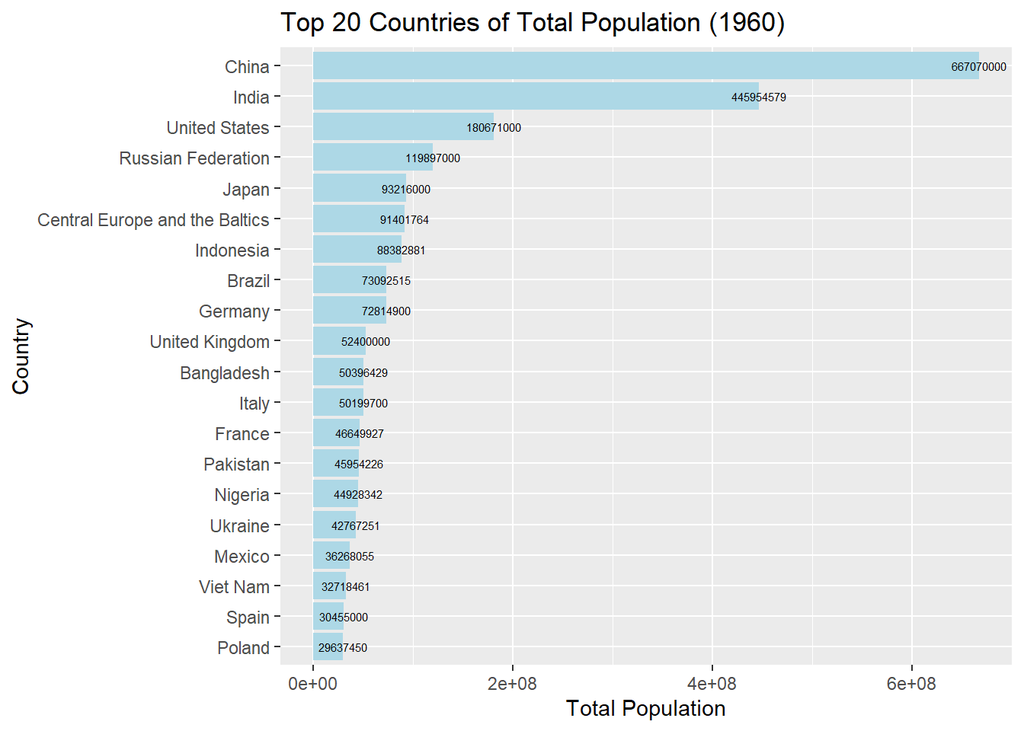

#### *FEMALE POPULATION*

[output not shown]

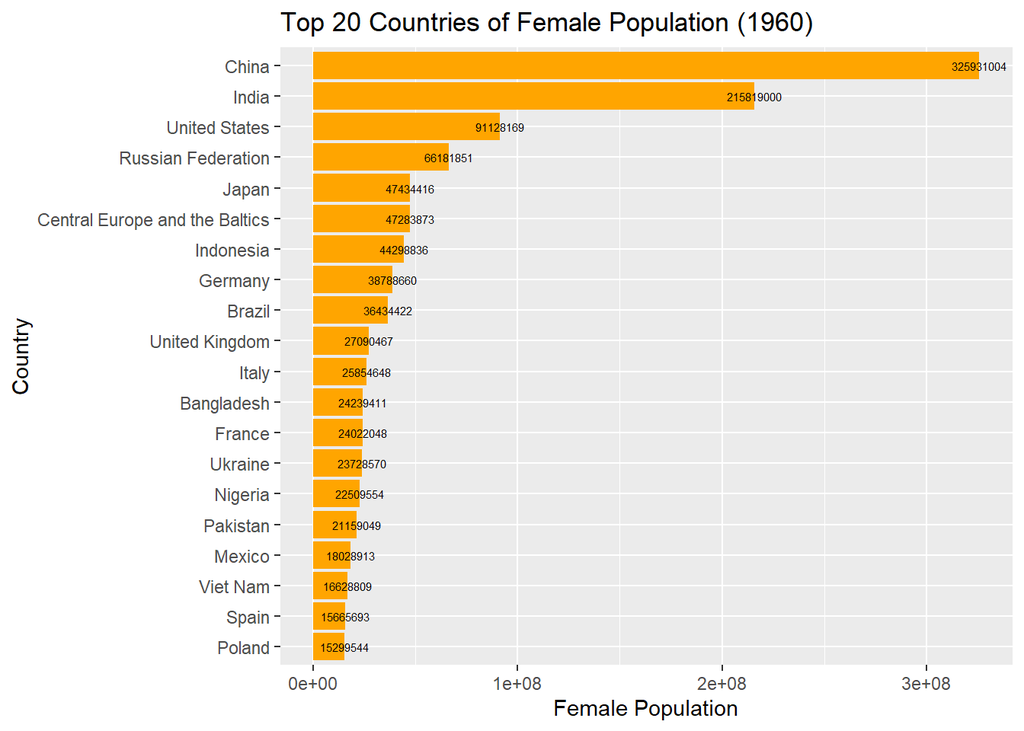

##### *MALE POPULATION*

[output not shown]

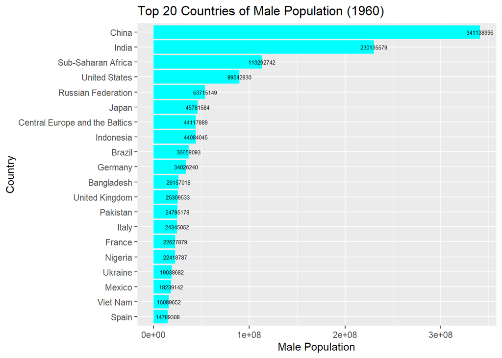

### 1990

#### *TOTAL POPULATION*

```
[1] "Top 20 countries of total population"
```

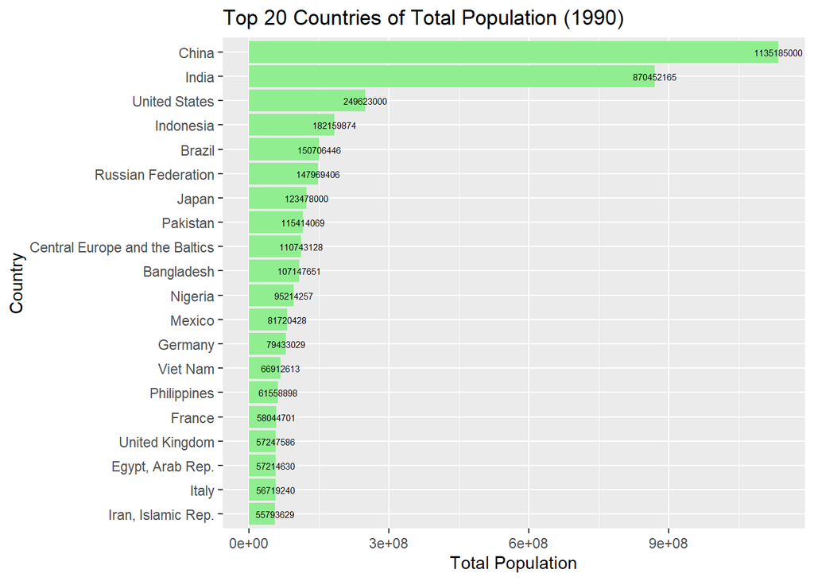

#### *FEMALE POPULATION*

```
[1] "Top 20 countries of female population"
```

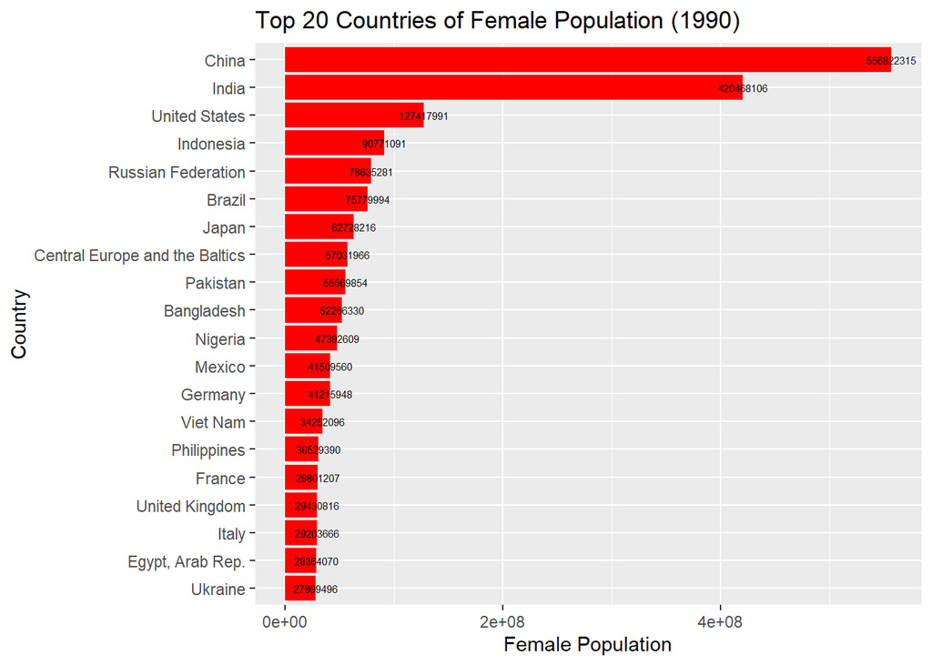

#### *MALE POPULATION*

[output not shown]

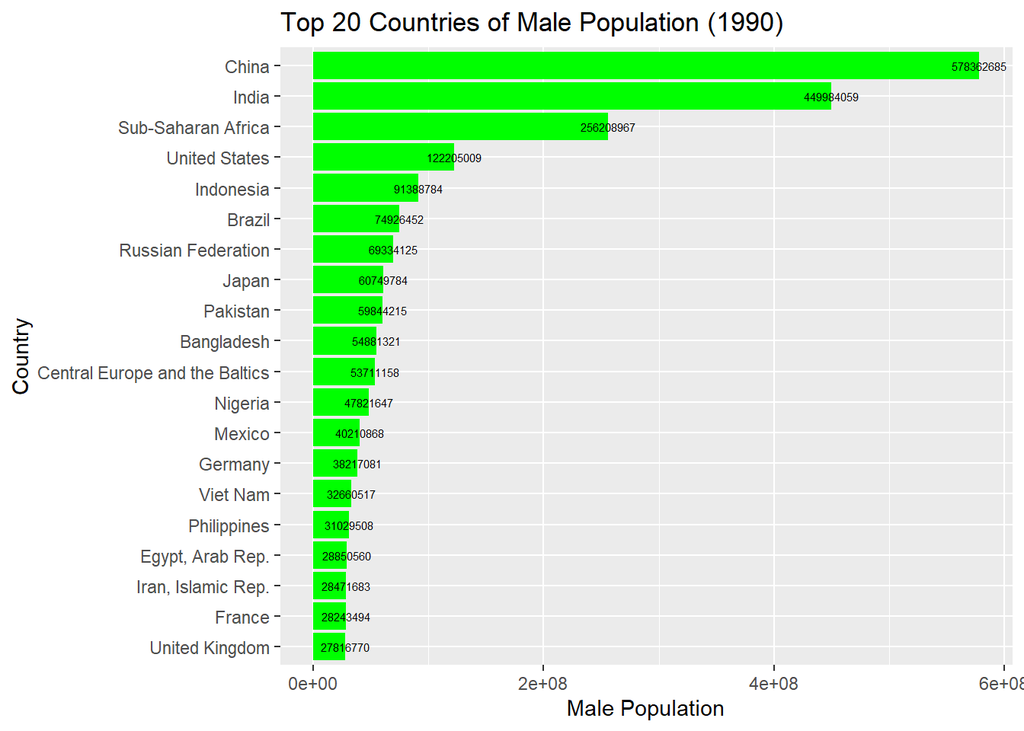

### 2023

##### *TOTAL POPULATION*

```
[1] "Top 20 countries of total population"
```

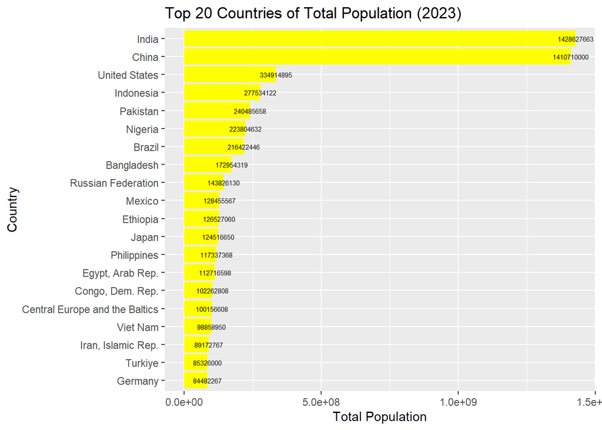

#### *FEMALE POPULATION*

```
[1] "Top 20 countries of female population"
```

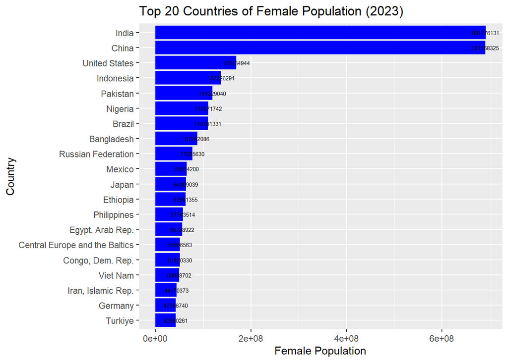

#### *MALE POPULATION*

```
[1] "Top 20 countries of male population"
```

[figure not shown]

## **Bottom 10 countries in 1960,1990,2023**

#### *TOTAL POPULATION IN 1960*

```
[1] "Bottom 10 countries of total population"
```

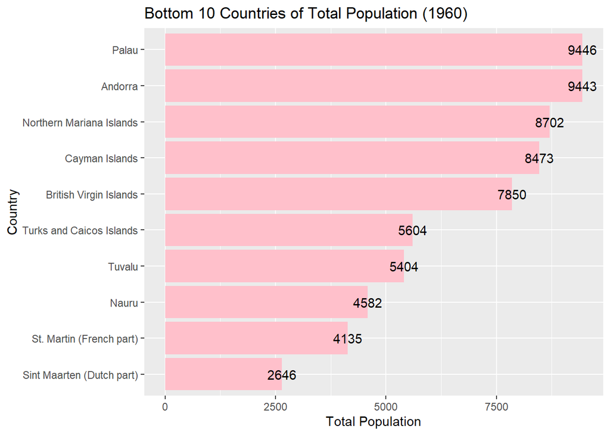

#### *TOTAL POPULATION IN 1990*

```
[1] "Bottom 10 countries of total population"
```

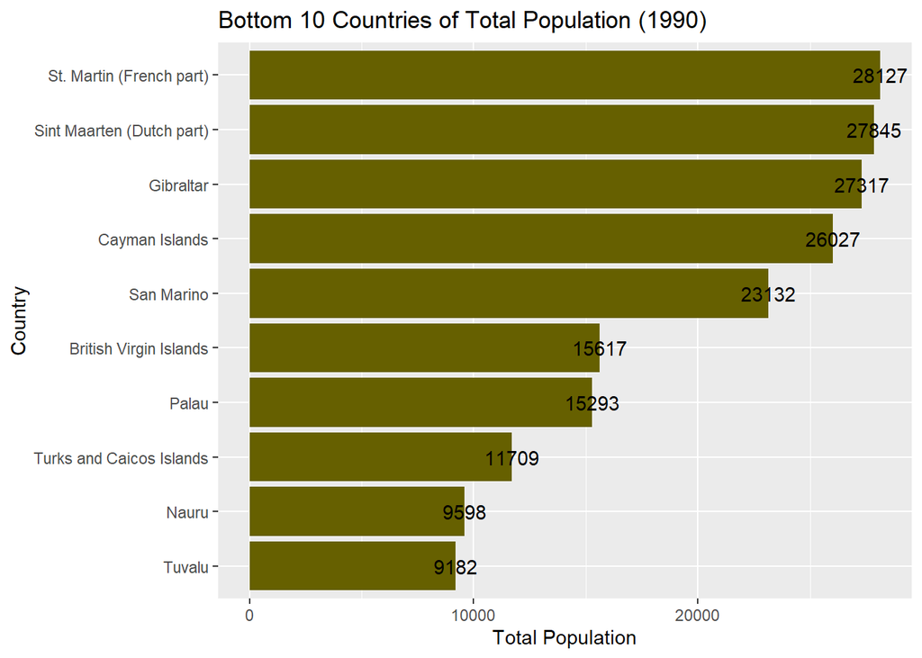

#### *TOTAL POPULATION IN 2023*

```
[1] "Bottom 10 countries of total population"
```

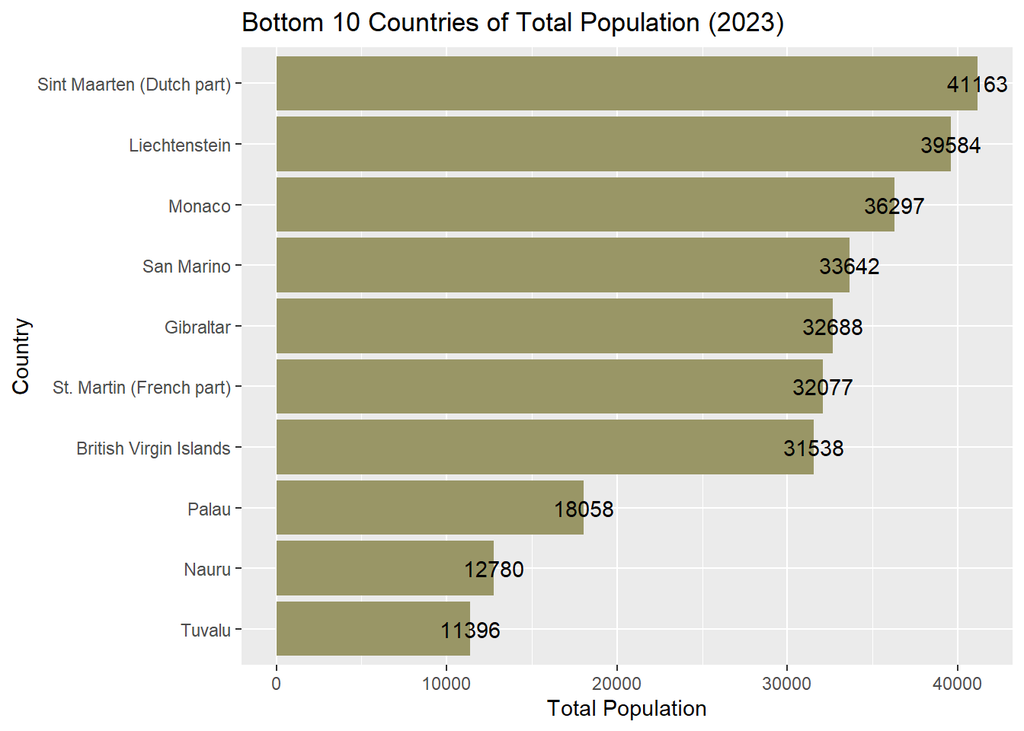

#### *Female vs Male from 1960,1990 and 2023 Bottom 10 countries*

```
[1] "Bottom 10 countries of female population in 1960"
```

```
                 Country.Name X1960
153                     Palau  4673
5                     Andorra  4670
38             Cayman Islands  4494
149  Northern Mariana Islands  4340
28     British Virgin Islands  3954
202  Turks and Caicos Islands  3075
203                    Tuvalu  2769
185  St. Martin (French part)  2109
140                     Nauru  1666
175 Sint Maarten (Dutch part)  1387
```

```
[1] "Bottom 10 countries of female population in 1990"
```

```
                 Country.Name X1990
175 Sint Maarten (Dutch part) 14037
185  St. Martin (French part) 13697
78                  Gibraltar 13366
38             Cayman Islands 13246
167                San Marino 11805
28     British Virgin Islands  7599
153                     Palau  7058
202  Turks and Caicos Islands  5642
203                    Tuvalu  4773
140                     Nauru  4579
```

```
[1] "Bottom 10 countries of female population in 2023"
```

```
                 Country.Name X2023
117             Liechtenstein 19942
175 Sint Maarten (Dutch part) 19157
133                    Monaco 18515
167                San Marino 17261
185  St. Martin (French part) 16834
78                  Gibraltar 16355
28     British Virgin Islands 16340
153                     Palau  8698
140                     Nauru  6293
203                    Tuvalu  5561
```

```
[1] "Bottom 10 countries of male population in 1960"
```

```
                 Country.Name X1960
5                     Andorra  4773
153                     Palau  4773
149  Northern Mariana Islands  4362
38             Cayman Islands  3979
28     British Virgin Islands  3897
140                     Nauru  2917
203                    Tuvalu  2635
202  Turks and Caicos Islands  2530
185  St. Martin (French part)  2026
175 Sint Maarten (Dutch part)  1258
```

```
[1] "Bottom 10 countries of male population in 1990"
```

```
                 Country.Name X1990
117             Liechtenstein 14295
78                  Gibraltar 13951
175 Sint Maarten (Dutch part) 13808
38             Cayman Islands 12781
167                San Marino 11328
153                     Palau  8236
28     British Virgin Islands  8017
202  Turks and Caicos Islands  6066
140                     Nauru  5019
203                    Tuvalu  4410
```

```
[1] "Bottom 10 countries of male population in 2023"
```

```
                Country.Name X2023
127         Marshall Islands 21425
117            Liechtenstein 19643
133                   Monaco 17783
167               San Marino 16381
78                 Gibraltar 16334
185 St. Martin (French part) 15242
28    British Virgin Islands 15197
153                    Palau  9359
140                    Nauru  6487
203                   Tuvalu  5835
```

#### *Plot 1960,1990 and 2023 Female vs Male*

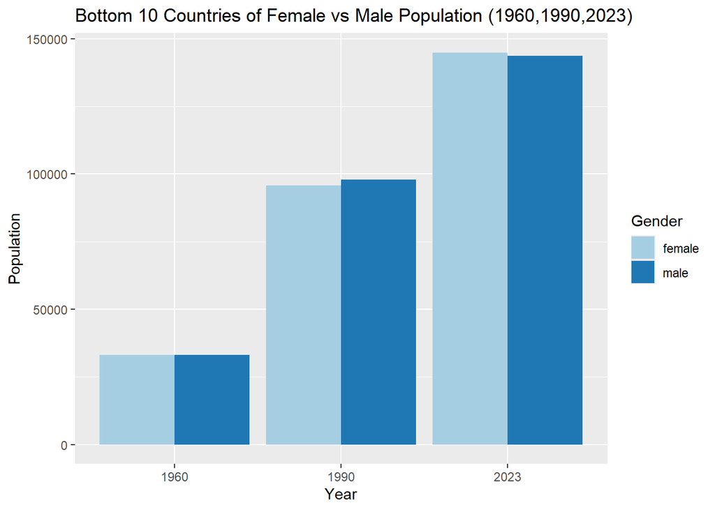

#### *Total Population in India from 1960 to 2023*

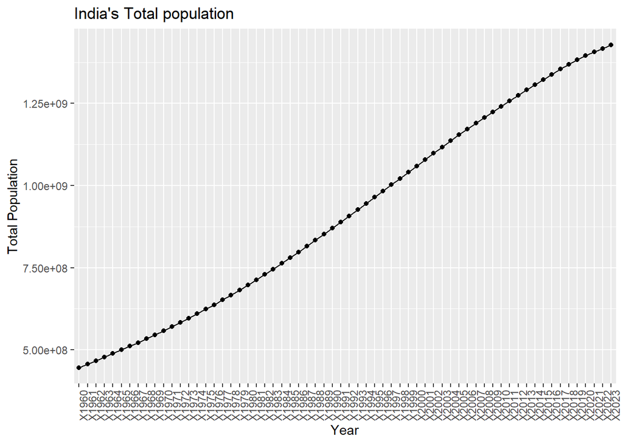

## *Comparison*

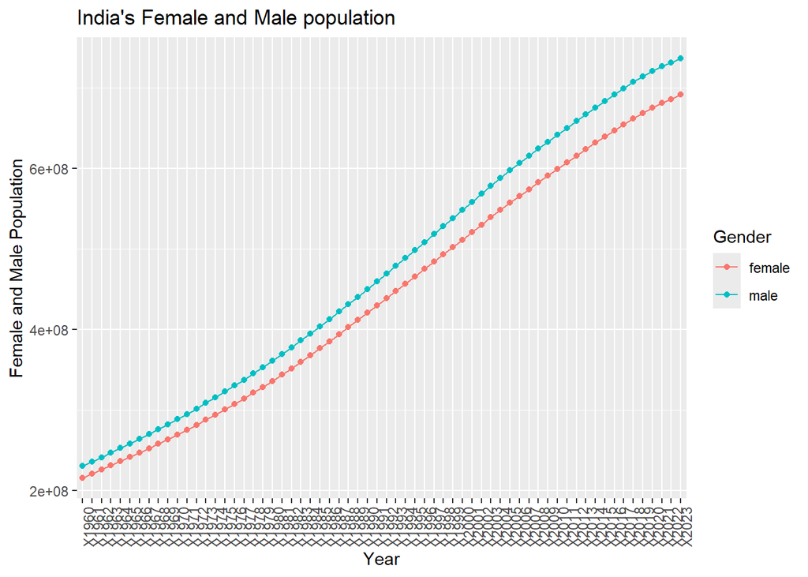

# CONCLUSION

This project provided a comprehensive analysis of global population trends from 1960 to 2023, focusing on total population, female population, and male population data. The datasets used in this study consisted of 217 rows and 68 columns, encompassing countries worldwide over the specified period. After verifying that there were no missing values, we streamlined the datasets by removing unnecessary columns, specifically the 2nd, 3rd, and 4th, to focus our analysis on the most relevant information. The country names were then displayed to ensure clarity in the data representation.

Given that population data is discrete, we utilized bar and column charts for visual representation. We selected three key years—1960, 1990, and 2023—to examine and compare the population distribution among the top 20 and bottom 10 countries in terms of total population, as well as gender-specific populations (female and male).

Gender-Specific Population Trends We further delved into gender-specific population trends by plotting paired bar diagrams for the bottom 10 countries in terms of male and female populations for the years 1960, 1990, and 2023:

1960: The populations of males and females in the bottom 10 countries were nearly equal, indicating a balanced gender distribution in these less populous regions. 1990: A noticeable shift occurred, with the male population surpassing the female population in the bottom 10 countries. This imbalance may reflect gender-specific migration patterns, birth rates, or other socio-economic factors prevalent at the time. 2023: The trend reversed, with the female population exceeding the male population in the bottom 10 countries. This shift could be attributed to various factors, including changes in life expectancy, migration trends, and gender-specific population policies. India’s Population Trends A special focus was given to India’s population trajectory from 1960 to 2023, using line diagrams to illustrate the trends:

Overall Population Growth: India’s total population exhibited a consistent upward trend, reflecting the country’s rapid population growth over the past six decades. Gender-Specific Growth: Both male and female populations in India have increased steadily over time. However, throughout this period, the male population has consistently been higher than the female population. This disparity highlights ongoing gender imbalances that have persisted despite overall population growth. Implications and Future Considerations The findings of this project highlight the importance of understanding and monitoring population trends, both globally and within specific countries. The shift in the world’s most populous country from China to India by 2023 is particularly significant, indicating potential changes in global economic and political dynamics.

The gender-specific analyses also provide valuable insights into the demographic challenges faced by different regions, particularly in terms of gender balance. These insights can inform future demographic policies, health initiatives, and socio-economic planning.

In conclusion, this study has provided a detailed examination of population dynamics over more than six decades, revealing significant trends and shifts that are crucial for policymakers, researchers, and planners as they prepare for the future.